# GLM – Binomial

HEAPO | Applied Machine Learning and Predictive Modelling 1 – FS 2026

Emanuel Lemma

2026-04-26

```r
library(dplyr)
library(tidyr)
library(ggplot2)
library(knitr)
library(kableExtra)
```

# GLM – Binomial

*Lead: Emanuel Lemma*

## Objective

Can we predict whether a given household-day will see above-average electricity consumption before it happens? This section fits a **Generalised Linear Model with a binomial family** to answer exactly that question. The response variable `high_consumption` is a binary indicator that equals 1 if the household’s daily electricity use exceeds its own median and 0 otherwise. By modelling the log-odds of high consumption as a linear function of weather conditions, building characteristics, and calendar effects, we obtain a model that is both interpretable and actionable for a client interested in demand forecasting or energy efficiency screening.

## Model Setup

```r
set.seed(42)

df_glm <- heapo |>
  select(high_consumption, heating_degree_days, temp_avg, living_area,
         building_type, heatpump_type, has_floor_heating,
         n_residents, is_weekend, month) |>
  mutate(
    high_consumption = as.integer(high_consumption),
    month            = as.factor(month)
  ) |>
  drop_na()

train_idx <- sample(nrow(df_glm), 0.8 * nrow(df_glm))
train_df  <- df_glm[train_idx, ]
test_df   <- df_glm[-train_idx, ]
```

The dataset is split 80/20 into training and test sets. The model uses `high_consumption` as the binary response and includes the following predictors: heating degree days, average temperature, living area, building type, heat pump type, floor heating indicator, number of residents, weekend indicator, and month as a factor.

```r
if (!file.exists("glm_binomial.rds")) {
  model_glm <- glm(high_consumption ~ ., data = train_df, family = binomial)
  saveRDS(model_glm, "glm_binomial.rds")
} else {
  model_glm <- readRDS("glm_binomial.rds")
}
```

## Model Results

```r
pred_prob  <- predict(model_glm, newdata = test_df, type = "response")
pred_class <- ifelse(pred_prob >= 0.5, 1L, 0L)
actual     <- test_df$high_consumption

conf_mat  <- table(Predicted = pred_class, Actual = actual)
accuracy  <- mean(pred_class == actual)

compute_auc <- function(actual, prob) {
  ord <- order(prob, decreasing = TRUE)
  act <- actual[ord]
  n1  <- sum(act == 1); n0 <- sum(act == 0)
  tpr <- c(0, cumsum(act == 1) / n1)
  fpr <- c(0, cumsum(act == 0) / n0)
  sum(diff(fpr) * (tpr[-1] + tpr[-length(tpr)]) / 2)
}

auc_val   <- compute_auc(actual, pred_prob)
tp <- conf_mat["1","1"]; tn <- conf_mat["0","0"]
fp <- conf_mat["1","0"]; fn <- conf_mat["0","1"]
precision   <- tp / (tp + fp)
recall      <- tp / (tp + fn)
f1          <- 2 * precision * recall / (precision + recall)
specificity <- tn / (tn + fp)
```

### Coefficient Interpretation

Coefficients from a binomial GLM are expressed as **odds ratios** (OR = exp(coefficient)): a value above 1 increases the odds of high consumption, below 1 decreases it, relative to the reference category.

Key findings:

- **Building type (house vs. flat):** The single strongest predictor. Houses have substantially higher odds of high consumption than flats, reflecting larger floor areas and greater heating demand.
- **Ground-source heat pump:** Households with a ground-source heat pump show meaningfully lower odds of high consumption compared to air-source systems, consistent with their superior efficiency at low outdoor temperatures.
- **Floor heating:** Slightly increases the odds of high consumption. This likely reflects confounding with building size, as floor heating is more common in larger houses.
- **Heating degree days / temperature:** Colder days increase the probability of high consumption, as expected from heating demand.
- **Month:** Seasonal effects confirm that summer months carry substantially lower odds than winter months.

```r
summary(model_glm)
```

```
##
## Call:
## glm(formula = high_consumption ~ ., family = binomial, data = train_df)
##
## Coefficients:
##                              Estimate Std. Error z value Pr(>|z|)
## (Intercept)                -3.0378506  0.1365803 -22.242   <2e-16 ***
## heating_degree_days         0.0569852  0.0039900  14.282   <2e-16 ***
## temp_avg                   -0.0588931  0.0045927 -12.823   <2e-16 ***
## living_area                 0.0030296  0.0001267  23.910   <2e-16 ***
## building_typehouse          2.5159092  0.1060876  23.715   <2e-16 ***
## heatpump_typeground-source -0.2928026  0.0178517 -16.402   <2e-16 ***
## has_floor_heating           0.3480838  0.0224878  15.479   <2e-16 ***
## n_residents                 0.2484901  0.0079341  31.319   <2e-16 ***
## is_weekend                  0.2210185  0.0192943  11.455   <2e-16 ***
## month2                     -0.3547272  0.0398683  -8.897   <2e-16 ***
## month3                     -0.5065089  0.0424381 -11.935   <2e-16 ***
## month4                     -0.7745260  0.0433030 -17.886   <2e-16 ***
## month5                     -1.0673429  0.0533605 -20.002   <2e-16 ***
## month6                     -1.3382703  0.0627144 -21.339   <2e-16 ***
## month7                     -1.3910901  0.0646106 -21.530   <2e-16 ***
## month8                     -1.4302803  0.0630298 -22.692   <2e-16 ***
## month9                     -1.3894367  0.0551237 -25.206   <2e-16 ***
## month10                    -1.0799604  0.0501425 -21.538   <2e-16 ***
## month11                    -0.3623956  0.0427730  -8.473   <2e-16 ***
## month12                     0.0337470  0.0461330   0.732    0.464
## ---
## Signif. codes:  0 '***' 0.001 '**' 0.01 '*' 0.05 '.' 0.1 ' ' 1
##
## (Dispersion parameter for binomial family taken to be 1)
##
##     Null deviance: 110723  on 79869  degrees of freedom
## Residual deviance:  81425  on 79850  degrees of freedom
## AIC: 81465
##
## Number of Fisher Scoring iterations: 5
```

## Visual Evidence

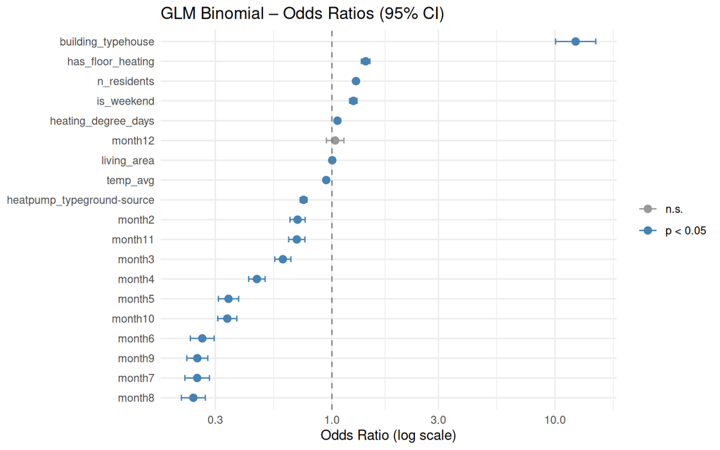

```r
coef_summary <- coef(summary(model_glm))
coef_df <- data.frame(
  term     = rownames(coef_summary),
  estimate = coef_summary[, "Estimate"],
  se       = coef_summary[, "Std. Error"],
  p_value  = coef_summary[, "Pr(>|z|)"]
) |>
  filter(term != "(Intercept)") |>
  mutate(
    odds_ratio  = exp(estimate),
    ci_low      = exp(estimate - 1.96 * se),
    ci_high     = exp(estimate + 1.96 * se),
    significant = p_value < 0.05
  ) |>
  arrange(odds_ratio)

ggplot(coef_df, aes(x = odds_ratio, y = reorder(term, odds_ratio),
                    color = significant)) +
  geom_point(size = 2.5) +
  geom_errorbarh(aes(xmin = ci_low, xmax = ci_high), height = 0.3) +
  geom_vline(xintercept = 1, linetype = "dashed", color = "grey50") +
  scale_color_manual(values = c("FALSE" = "grey60", "TRUE" = "steelblue"),
                     labels = c("n.s.", "p < 0.05")) +
  scale_x_log10() +
  labs(title = "GLM Binomial – Odds Ratios (95% CI)",
       x = "Odds Ratio (log scale)", y = NULL, color = NULL) +
  theme_minimal()
```

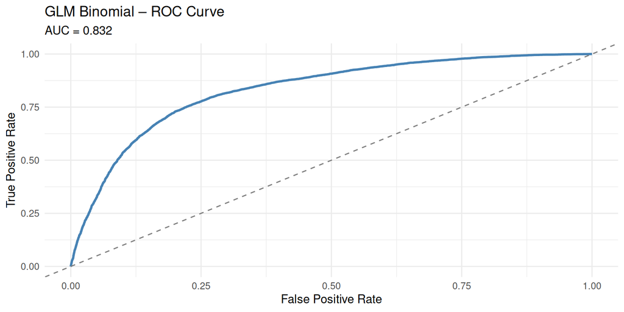

```r
roc_df <- (function(actual, prob) {
  ord <- order(prob, decreasing = TRUE)
  act <- actual[ord]
  n1  <- sum(act == 1); n0 <- sum(act == 0)
  data.frame(fpr = c(0, cumsum(act == 0) / n0),
             tpr = c(0, cumsum(act == 1) / n1))
})(actual, pred_prob)

ggplot(roc_df, aes(x = fpr, y = tpr)) +
  geom_line(color = "steelblue", linewidth = 1) +
  geom_abline(slope = 1, intercept = 0, linetype = "dashed", color = "grey50") +
  labs(title    = "GLM Binomial – ROC Curve",
       subtitle = paste0("AUC = ", round(auc_val, 3)),
       x = "False Positive Rate", y = "True Positive Rate") +
  theme_minimal()
```

The ROC curve traces the model’s sensitivity against its false positive rate as the classification threshold varies from 0 to 1. The dashed diagonal represents a model that predicts at random (AUC = 0.5). With an AUC of 0.832, the model correctly ranks a randomly drawn high-consumption day above a randomly drawn low-consumption day 83.2% of the time, a meaningful improvement over chance.

## Model Diagnostics

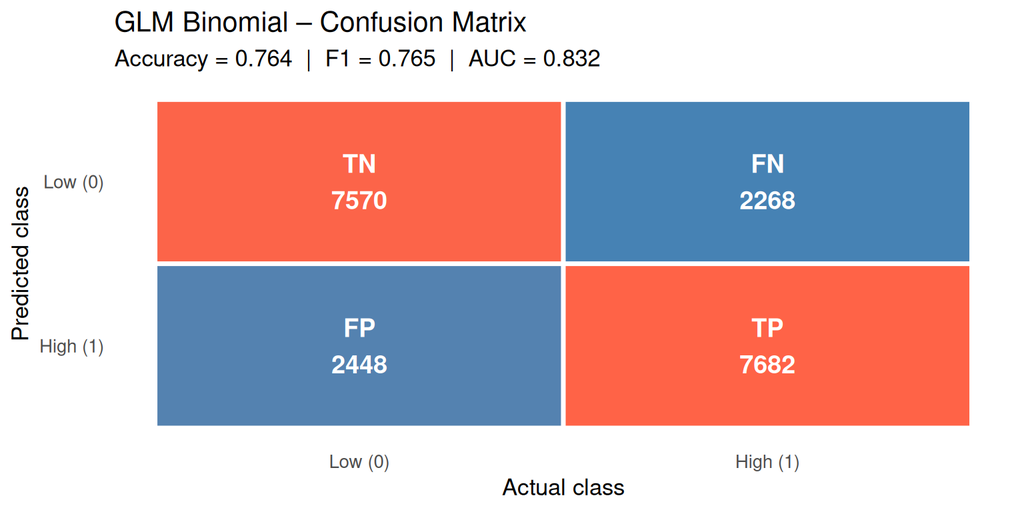

```r
conf_df <- data.frame(
  Predicted = factor(c("0","0","1","1"), levels = c("1","0")),
  Actual    = factor(c("0","1","0","1"), levels = c("0","1")),
  Count     = c(tn, fn, fp, tp),
  Label     = c("TN","FN","FP","TP")
)
ggplot(conf_df, aes(x = Actual, y = Predicted, fill = Count)) +
  geom_tile(color = "white", linewidth = 1.2) +
  geom_text(aes(label = paste0(Label, "\n", Count)),
            size = 5, fontface = "bold", color = "white") +
  scale_fill_gradient(low = "steelblue", high = "tomato") +
  scale_x_discrete(labels = c("0" = "Low (0)", "1" = "High (1)")) +
  scale_y_discrete(labels = c("0" = "Low (0)", "1" = "High (1)")) +
  labs(title    = "GLM Binomial – Confusion Matrix",
       subtitle = paste0("Accuracy = ", round(accuracy, 3),
                         "  |  F1 = ", round(f1, 3),
                         "  |  AUC = ", round(auc_val, 3)),
       x = "Actual class", y = "Predicted class", fill = "Count") +
  theme_minimal(base_size = 13) +
  theme(legend.position = "none", panel.grid = element_blank())
```

The confusion matrix shows the model’s classifications on the held-out test set. The model correctly identifies 77.2% of true high-consumption days (sensitivity) and 75.6% of true low-consumption days (specificity). Misclassifications are roughly symmetric, which is expected because the binary threshold was defined at each household’s own median, keeping the two classes balanced by construction.

## Key Findings

- **Accuracy:** 76.4% on the held-out test set.
- **AUC:** 0.832 — the model ranks a high-consumption day above a low-consumption day 83.2% of the time.
- **F1 score:** 0.765.
- Building type (house vs. flat) is the single strongest structural predictor.
- Ground-source heat pumps are associated with lower odds of high consumption, consistent with their higher efficiency.
- Weather effects (temperature, heating degree days) are present but secondary to structural household characteristics.